# 비지도학습이란?

##### 지도학습과는 달리 정답(Y)이 없는 데이터를 가지고 학습하는 것이다

##### 비지도학습의 목표는 해당 데이터의 패턴, 특성 및 구조를 스스로 파악하여 이를 통해 데이터가 어떻게 구성되었는지 새로운 규칙성을 알아내는 과정

##### 비지도학습은 크게 군집분석과 차원축소로 나눌 수 있다

### Clustering - 군집분석

##### 군집분석은 비지도학습(unsupervised learning)의 일종으로 유사한 데이터끼리 그룹화를 시키는 학습모델을 말한다. 각 데이터의 유사성을 측정하여, 유사성이 높은 집단끼리 분류하고 군집간에 상이성을 규명하는 방법이다

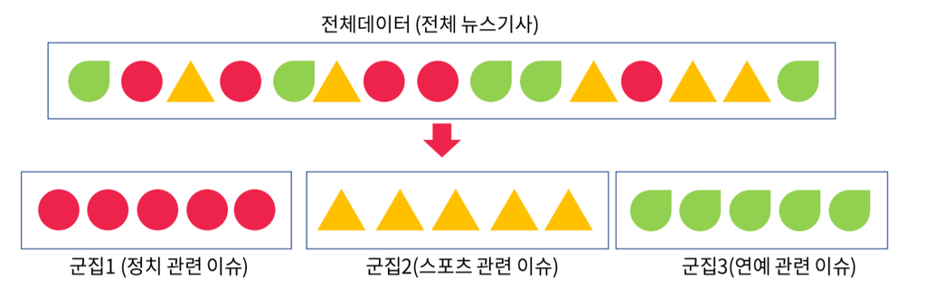

```python
from IPython.display import Image
image_path = 'C:/Users/jaemi/OneDrive/Desktop/비지도학습/kmeans/img1.png'
Image(filename=image_path, width=800)
```

##### 위의 그림을 보면 raw data에는 여러가지 종류가 섞여있다. 섞여있는 raw data를 군집분석을 통해 서로 다른 특성을 가진 군집으로 분류한다. 이때, 분류문제와는 다르게 target Y가 존재하지 않는다. 그렇기에 학습과정에 있어서 정답을 맞출 기준표가 없는 것이다.

##### 위의 그림은 기사에 대한 군집분석을 보여준다. 각 군집은 이슈별로 정리된 결과를 도출했다. 이처럼 군집분석은 raw data에서 segmentation을 통해 insight를 도출하고, 이를 특정 활용하여 마케팅/특정 프로모션등으로 활용할 수 있다. 물론 군집 별 추가 분석을 수행하여 새로운 더 심화적인 insight를 도출할 수도 있다.

##### 이러한Clustering의 종류로는 대표적으로

##### -K-means clustering : 데이터를 사용자가 지정한 k개의 군집으로 나눈다.

##### -계층적 군집분석(Hierarchical clustering) : 나무 모양의 계층적 구조를 형성하여 군집분석을 수행한다.

##### -DBSCAN : k개를 설정할 필요없이 인근에 있는 데이터를 따라가며 군집화 할 수 있다.

##### 와 같은 종류들이 있다

### DBSCAN clustering

##### K-means clustering은 초기 중심으로 설정한 값에 크게 영향을 받고 노이즈와 아웃라이어에 민감하다는 단점이 있다.

##### 그리고 군집의 개수 K를 설정하는 것도 쉽지 않다는 단점이 있었다.

##### 이러한 단점을 상대적으로 극복한 것이 DBSCAN clustering이다.

##### DBSCAN의 가장 대표적인 특징은 eps-neighbors와 MinPts를 사용하여 군집을 구성한다는 것이다.

##### Eps-neighbors는 한 데이터를 중심으로 epsilon 거리 이내에 데이터를 한 군집으로 구성한다고 명시하는 parameter이다.

##### MinPts는 한 군집은 MinPts보다 많거나 같은 수의 데이터로 구성된다는 것이다.

##### 만약 MinPts보다 적은 수의 데이터가 eps-neighbors를 형성하면 noise로 취급을 한다. 즉, 군집은 최소한의 일정 데이터수를 유지해야한다는 것이다.

##### DBSCAN의 학습과정은 아래의 그림을 통해서 알 수 있다.

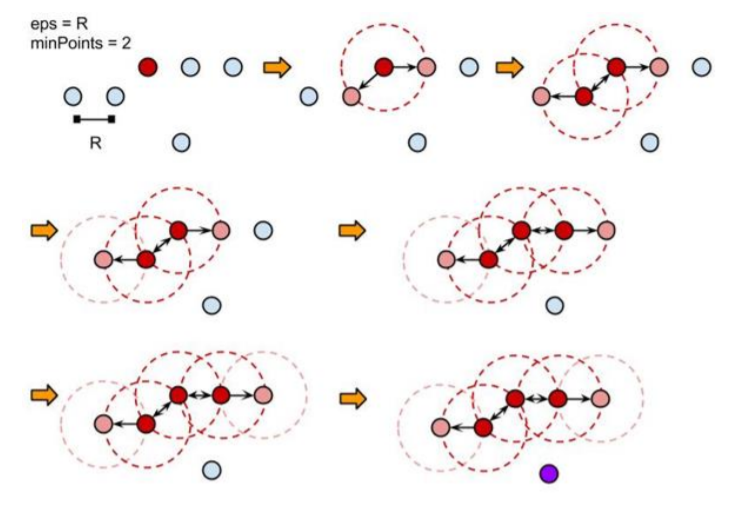

```python
image_path = 'C:/Users/jaemi/OneDrive/Desktop/비지도학습/dbscan/img1.png'
Image(filename=image_path, width=800)
```

##### 사용자는 eps와 minPoints를 parameter로 지정한다. 군집이 형성될 개수K를 parameter로 설정하지 않는 것이다.

##### 그리고 eps를 반지름하는 원 안에 있는 관측치를 찾는다. 찾으면 그 관측치를 군집내 포함시키고, 해당 관측치를 기준으로 다시 관측치를 찾아나선다.

##### 이 군집이 최소한의 관측치 개수 minPoints를 넘기면 군집으로 인정이 되는 것이다. 그리고 연결되지 않은 관측치들은 이상치로 분류한다.

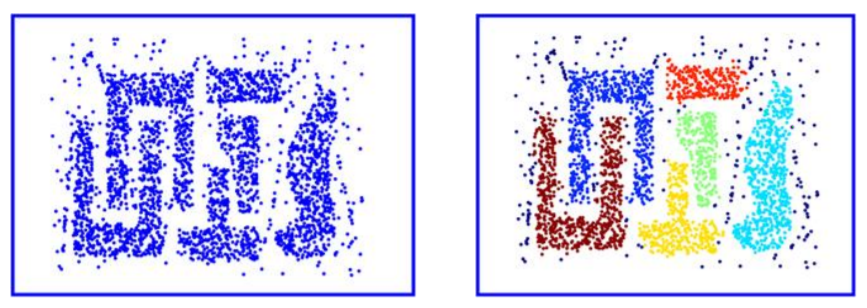

```python
image_path = 'C:/Users/jaemi/OneDrive/Desktop/비지도학습/dbscan/img2.png'
Image(filename=image_path, width=800)
```

##### DBSCAN의 가장 큰 장점은 원형이 아닌 데이터들의 군집을 잘 분류해내고, 이상치에 반응을 하지 않는다는 것이다.

##### 그리고 K-means/medoids처럼 군집의 수를 설정할 필요가 없다.

##### DBSCAN으로 군집을 잘 분류해내려면 Eps와 MinPoints parameter를 잘 설정할 필요가 있다.

##### 이는 데이터에 대한 이해도가 충분할 경우에 상대적으로 쉬워진다.

##### Minpoints는 가장 기본적으로는 변수의 수 + 1로 이루어진다. 그리고 최소한 3이상으로 설정할 필요가 있다.

##### 왜냐하면, 1인 경우는 데이터 하나하나가 모두 군집인 것으로 판단이 되기 때문이다.

##### Eps설정의 경우에는 eps가 너무 작을경우 상당 수의 데이터가 노이즈로 구분되어 무시될 수 있다.

##### 그렇다고 너무 클 경우는 모든 데이터가 하나의 군집으로 될 수도 있다. 그렇기에 eps를 잘 설정하는 것이 중요하다.

### DBSCAN 파이썬 실습

#### 1. 데이터 준비

##### K-means 실습과 마찬가지로 sklearn에서 제공해주는 iris 데이터를 사용한다.

##### clustering이기에 종속변수를 제외하고 독립변수만으로 데이터프레임을 구성한다.

```python
#실습 데이터 Load & Dataframe 변환
from sklearn import datasets
import pandas as pd

iris = datasets.load_iris()
y = pd.DataFrame(iris.target)
y.columns=['labels']
data = pd.DataFrame(iris.data)
data.columns=['Sepal length','Sepal width','Petal length','Petal width']
data = pd.concat([data,y],axis=1)

data.head()
```

|  | Sepal length | Sepal width | Petal length | Petal width | labels |
| --- | --- | --- | --- | --- | --- |
| 0 | 5.1 | 3.5 | 1.4 | 0.2 | 0 |
| 1 | 4.9 | 3.0 | 1.4 | 0.2 | 0 |
| 2 | 4.7 | 3.2 | 1.3 | 0.2 | 0 |
| 3 | 4.6 | 3.1 | 1.5 | 0.2 | 0 |
| 4 | 5.0 | 3.6 | 1.4 | 0.2 | 0 |

```python
df = data[ ['Sepal length','Sepal width','Petal length','Petal width']]
df.head()
```

|  | Sepal length | Sepal width | Petal length | Petal width |
| --- | --- | --- | --- | --- |
| 0 | 5.1 | 3.5 | 1.4 | 0.2 |
| 1 | 4.9 | 3.0 | 1.4 | 0.2 |
| 2 | 4.7 | 3.2 | 1.3 | 0.2 |
| 3 | 4.6 | 3.1 | 1.5 | 0.2 |
| 4 | 5.0 | 3.6 | 1.4 | 0.2 |

#### 2. DBSCAN 모델 학습

##### sklearn의 모든 모델들과 같이 .fit명령어로 학습한다.

##### clustering은 비지도 학습이므로 독립변수만을 입력으로 받는다.

##### parameter로 eps=0.5, min_sample=5를 지정해 주었다.

##### 위에서 설명했듯이 eps는 여기서 한 데이터가 주변에 얼만큼 떨어진 거리를 같은 군집으로 생각할지의 기준에서 거리이다

##### 그리고 min_samples는 적어도 한 군집에는 5개의 sample들이 모여야 군집으로 인정한다는 것이다.

```python
from sklearn.cluster import DBSCAN
import matplotlib.pyplot  as plt
import seaborn as sns

# create model and prediction
model = DBSCAN(eps=0.5,min_samples=5)
cluster = pd.DataFrame(model.fit_predict(df))
cluster.columns=['cluster']

# concatenate labels to df as a new column
r = pd.concat([df,cluster],axis=1)

print(r)
```

```
     Sepal length  Sepal width  Petal length  Petal width  cluster
0             5.1          3.5           1.4          0.2        0
1             4.9          3.0           1.4          0.2        0
2             4.7          3.2           1.3          0.2        0
3             4.6          3.1           1.5          0.2        0
4             5.0          3.6           1.4          0.2        0
..            ...          ...           ...          ...      ...
145           6.7          3.0           5.2          2.3        1
146           6.3          2.5           5.0          1.9        1
147           6.5          3.0           5.2          2.0        1
148           6.2          3.4           5.4          2.3        1
149           5.9          3.0           5.1          1.8        1

[150 rows x 5 columns]
```

#### 3. 결과 시각화

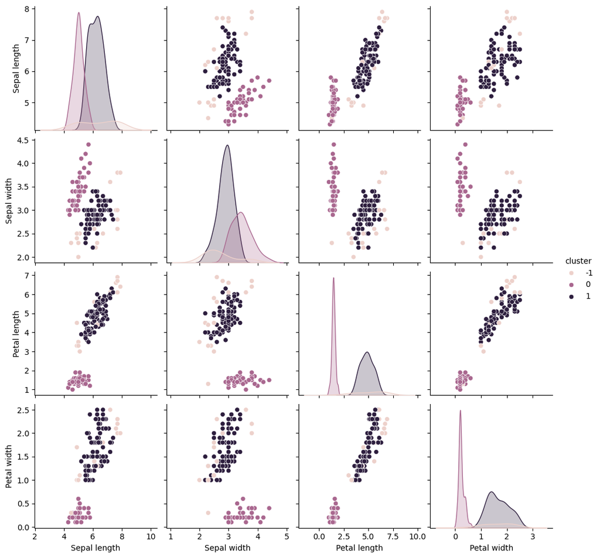

```python
#pairplot with Seaborn
sns.pairplot(r,hue='cluster')
plt.show()
```